# 01-Model: Count Vectorizer/TF IDF Vectorizer

**Topic:** Real or Not? NLP with Disaster Tweets  
**Class:** MSCA 31009 Machine Learning  
**Professor:** Dr. Arnab Bose  
**Link:** https://www.kaggle.com/c/nlp-getting-started/overview

**Table of contents**

1. Overview
2. Importing the libraries
3. Dataset
4. Dataset preperation
5. Visualization
6. Count Vectorizer + RF/SVM/NB/Logistic
7. TFIDF Vectorizer + RF

**Please Note: The best model in this notebook is Counter Vectorizer and Logistic Model**

## 1. Overview

Build a machine learning model that predicts which Tweets are about real disasters and which one’s aren’t. We have access to a dataset of 10,000 tweets that were hand classified.

## 2. Importing libraries

```python
import pandas as pd
import matplotlib.pyplot as plt
import seaborn as sns
from nltk.tokenize import word_tokenize
import re
from nltk.corpus import stopwords
from nltk.stem import WordNetLemmatizer
import nltk
from collections import Counter
from sklearn.feature_extraction.text import CountVectorizer
from sklearn.feature_extraction.text import TfidfVectorizer
from sklearn.naive_bayes import MultinomialNB
from sklearn import metrics
from sklearn.ensemble import RandomForestClassifier
from sklearn.svm import SVC
from sklearn.model_selection import GridSearchCV
from sklearn.linear_model import LogisticRegression
from sklearn.pipeline import Pipeline
from sklearn.preprocessing import MaxAbsScaler
```

```python
# Set additional parameters for charts and tables
# Remove column display limits
pd.set_option('display.max_columns', None)
pd.set_option('display.max_rows', None)
plt.rcParams['figure.figsize'] = [15, 10]
plt.style.use('seaborn-whitegrid')
```

## 3. Dataset

```python
train_df = pd.read_csv("../Data/train.csv",index_col=0)
test_df = pd.read_csv("../Data/test.csv",index_col=0)
```

```python
train_df.head(10)
```

| id | keyword | location | text | target |
| --- | --- | --- | --- | --- |
| 1 | NaN | NaN | Our Deeds are the Reason of this #earthquake M... | 1 |
| 4 | NaN | NaN | Forest fire near La Ronge Sask. Canada | 1 |
| 5 | NaN | NaN | All residents asked to 'shelter in place' are ... | 1 |
| 6 | NaN | NaN | 13,000 people receive #wildfires evacuation or... | 1 |
| 7 | NaN | NaN | Just got sent this photo from Ruby #Alaska as ... | 1 |
| 8 | NaN | NaN | #RockyFire Update => California Hwy. 20 closed... | 1 |
| 10 | NaN | NaN | #flood #disaster Heavy rain causes flash flood... | 1 |
| 13 | NaN | NaN | I'm on top of the hill and I can see a fire in... | 1 |
| 14 | NaN | NaN | There's an emergency evacuation happening now ... | 1 |
| 15 | NaN | NaN | I'm afraid that the tornado is coming to our a... | 1 |

```python
test_df.head(10)
```

| id | keyword | location | text |
| --- | --- | --- | --- |
| 0 | NaN | NaN | Just happened a terrible car crash |
| 2 | NaN | NaN | Heard about #earthquake is different cities, s... |
| 3 | NaN | NaN | there is a forest fire at spot pond, geese are... |
| 9 | NaN | NaN | Apocalypse lighting. #Spokane #wildfires |
| 11 | NaN | NaN | Typhoon Soudelor kills 28 in China and Taiwan |
| 12 | NaN | NaN | We're shaking...It's an earthquake |
| 21 | NaN | NaN | They'd probably still show more life than Arse... |
| 22 | NaN | NaN | Hey! How are you? |
| 27 | NaN | NaN | What a nice hat? |
| 29 | NaN | NaN | Fuck off! |

## 4. Dataset preperation

**Pre processing**

- Tokenization
- Lowercasing the words
- Lemmatization/Stemming (shorten words to their root stems)
  - *Stemming usually refers to a crude heuristic process that chops off the ends of words in the hope of achieving this goal correctly most of the time, and often includes the removal of derivational affixes.
  - *Lemmatization usually refers to doing things properly with the use of a vocabulary and morphological analysis of words, normally aiming to remove inflectional endings only and to return the base or dictionary form of a word*
- Removing stop words
- Cleaning

**Shape of the dataframe**

```python
print("The train is {}".format(train_df.shape))
print("The test is {}".format(test_df.shape))
```

```
The train is (7613, 4)
The test is (3263, 3)
```

**Looking at the null values**

```python
(train_df.isnull().sum()/train_df.shape[0])*100
```

```
keyword      0.801261
location    33.272035
text         0.000000
target       0.000000
dtype: float64
```

- 33% of the tweets don't have locations in the training dataset

```python
(test_df.isnull().sum()/test_df.shape[0])*100
```

```
keyword      0.796813
location    33.864542
text         0.000000
dtype: float64
```

**Checking duplicates and removing them**

```python
#for train
print(train_df.duplicated().sum())
train_df = train_df.drop_duplicates()
```

```
52
```

**Making all the text lowercase**

```python
#lower case all the text
train_df['text']=train_df.apply(lambda row:row['text'].lower(),axis=1)
test_df['text']=test_df.apply(lambda row:row['text'].lower(),axis=1)
```

**Removing the links from the text**

```python
train_df['text']=train_df.apply(lambda row:re.sub(r"//t.co/\w+","",row['text']),axis=1)
test_df['text']=test_df.apply(lambda row:re.sub(r"//t.co/\w+","",row['text']),axis=1)
```

**Removing the @ and #**

```python
def find_hashtags(tweet):
    return " ".join([match.group(0)[1:] for match in re.finditer(r"#\w+", tweet)]) or 'no'

def find_mentions(tweet):
    return " ".join([match.group(0)[1:] for match in re.finditer(r"@\w+", tweet)]) or 'no'

def process_text(df):
    df['hashtags'] = df['text'].apply(lambda x: find_hashtags(x))
    df['mentions'] = df['text'].apply(lambda x: find_mentions(x))
    return df

train_df = process_text(train_df)
test_df = process_text(test_df)
```

```python
#for #
train_df['text']=train_df.apply(lambda row:re.sub(r"#","",row['text']),axis=1)
test_df['text']=test_df.apply(lambda row:re.sub(r"#","",row['text']),axis=1)
```

```python
#for @
train_df['text']=train_df.apply(lambda row:re.sub(r"@\w+","",row['text']),axis=1)
test_df['text']=test_df.apply(lambda row:re.sub(r"@\w+","",row['text']),axis=1)
```

**Removing the HTML Tags**

```python
train_df['text']=train_df.apply(lambda row:re.sub(r"<.*?>","",row['text']),axis=1)
test_df['text']=test_df.apply(lambda row:re.sub(r"<.*?>","",row['text']),axis=1)
```

**Removing URL's**

```python
train_df['text']=train_df.apply(lambda row:re.sub(r"https?://\S+|www\.\S+","",row['text']),axis=1)
test_df['text']=test_df.apply(lambda row:re.sub(r"https?://\S+|www\.\S+","",row['text']),axis=1)
```

**Removing Emoji's**

```python
# Reference : https://gist.github.com/slowkow/7a7f61f495e3dbb7e3d767f97bd7304b
def remove_emoji(text):
    emoji_pattern = re.compile("["
                           u"\U0001F600-\U0001F64F"  # emoticons
                           u"\U0001F300-\U0001F5FF"  # symbols & pictographs
                           u"\U0001F680-\U0001F6FF"  # transport & map symbols
                           u"\U0001F1E0-\U0001F1FF"  # flags (iOS)
                           u"\U00002702-\U000027B0"
                           u"\U000024C2-\U0001F251"
                           "]+", flags=re.UNICODE)
    return emoji_pattern.sub(r'', text)

remove_emoji("Omg another Earthquake 😔😔 ")
```

```
'Omg another Earthquake  '
```

```python
train_df['text']=train_df['text'].apply(lambda x: remove_emoji(x))
test_df['text']=test_df['text'].apply(lambda x: remove_emoji(x))
```

**Removing line breaks and tabs**

```python
train_df['text']=train_df.apply(lambda row:re.sub(r"\n","",row['text']),axis=1)
test_df['text']=test_df.apply(lambda row:re.sub(r"\n","",row['text']),axis=1)
train_df['text']=train_df.apply(lambda row:re.sub(r"\t","",row['text']),axis=1)
test_df['text']=test_df.apply(lambda row:re.sub(r"\t","",row['text']),axis=1)
```

**Removing extra spaces**

```python
train_df['text']=train_df.apply(lambda row:re.sub(r"\s"," ",row['text'].strip()),axis=1)
test_df['text']=test_df.apply(lambda row:re.sub(r"\s"," ",row['text'].strip()),axis=1)
```

```python
train_df.head()
```

| id | keyword | location | text | target | hashtags | mentions |
| --- | --- | --- | --- | --- | --- | --- |
| 1 | NaN | NaN | our deeds are the reason of this earthquake ma... | 1 | earthquake | no |
| 4 | NaN | NaN | forest fire near la ronge sask. canada | 1 | no | no |
| 5 | NaN | NaN | all residents asked to 'shelter in place' are ... | 1 | no | no |
| 6 | NaN | NaN | 13,000 people receive wildfires evacuation ord... | 1 | wildfires | no |
| 7 | NaN | NaN | just got sent this photo from ruby alaska as s... | 1 | alaska wildfires | no |

## 5. Visualizations

**Class balance**

```python
#function to get distrubution of the cat variables
def get_distr_cat(df,feature):
    sns.set()
    plt.figure(figsize=(10,8))
    sns.barplot(x=df[feature].value_counts().index,y=df[feature].value_counts(),palette="husl")
```

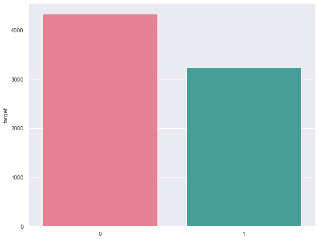

```python
get_distr_cat(train_df,'target')
```

## 6. Count Vectorizer +Naive Bayes

**Kaggle Accuracy Achieved: 0.77444**

**Bag of words approach**

- Create tokens and count of all the tokens
- The more frequent a token is, the more important that word might be

**Naive Bayes**

- Usually used with NLP problems as it's basis is in probability
- *Given a particular data how likely is a particular outcome*

```python
#splitting the data into X and Y
X_train=train_df['text']
X_test=test_df['text']
y_train=train_df['target']
```

```python
X_train.head()
```

```
id
1    our deeds are the reason of this earthquake ma...
4               forest fire near la ronge sask. canada
5    all residents asked to 'shelter in place' are ...
6    13,000 people receive wildfires evacuation ord...
7    just got sent this photo from ruby alaska as s...
Name: text, dtype: object
```

```python
X_test.head()
```

```
id
0                    just happened a terrible car crash
2     heard about earthquake is different cities, st...
3     there is a forest fire at spot pond, geese are...
9                apocalypse lighting. spokane wildfires
11        typhoon soudelor kills 28 in china and taiwan
Name: text, dtype: object
```

```python
y_train.head()
```

```
id
1    1
4    1
5    1
6    1
7    1
Name: target, dtype: int64
```

```python
count_vectorizer=CountVectorizer(stop_words='english',min_df = 1)
#creating a bag of words vector
count_train=count_vectorizer.fit_transform(X_train)

#create bag words for testing data using same dictionary
count_test=count_vectorizer.transform(X_test)

#to get dataframe
count_train_df = pd.DataFrame(count_train.toarray(), columns=count_vectorizer.get_feature_names())
count_test_df = pd.DataFrame(count_test.toarray(), columns=count_vectorizer.get_feature_names())
```

```python
# Mentions
vec_men = CountVectorizer(min_df = 5)
men_vec = vec_men.fit_transform(train_df['mentions'])
men_vec_test = vec_men.transform(test_df['mentions'])
X_train_men = pd.DataFrame(men_vec.toarray(), columns=vec_men.get_feature_names())
X_test_men = pd.DataFrame(men_vec_test.toarray(), columns=vec_men.get_feature_names())

# Hashtags
vec_hash = CountVectorizer(min_df = 5)
hash_vec = vec_hash.fit_transform(train_df['hashtags'])
hash_vec_test = vec_hash.transform(test_df['hashtags'])
X_train_hash = pd.DataFrame(hash_vec.toarray(), columns=vec_hash.get_feature_names())
X_test_hash = pd.DataFrame(hash_vec_test.toarray(), columns=vec_hash.get_feature_names())
print ( X_train_men.shape, X_train_hash.shape)
```

```
(7561, 18) (7561, 100)
```

```python
count_train_df = count_train_df.join(X_train_men, rsuffix='_mention')
count_train_df = count_train_df.join(X_train_hash, rsuffix='_hashtag')

count_test_df = count_test_df.join(X_test_men, rsuffix='_mention')
count_test_df = count_test_df.join(X_test_hash, rsuffix='_hashtag')
```

```python
count_train_df.head()
```

|  | 00 | 000 | 0000 | 00end | 00pm | 01 | 02 | 0215 | 02pm | 03 | 030 | 033 | 034 | 039 | 04 | 05 | 05th | 06 | 060 | 061 | 06jst | 07 | 08 | 0840728http | 0853 | 087809233445 | 0880 | 09 | 0l | … |
| --- | --- | --- | --- | --- | --- | --- | --- | --- | --- | --- | --- | --- | --- | --- | --- | --- | --- | --- | --- | --- | --- | --- | --- | --- | --- | --- | --- | --- | --- | --- |
| 0 | 0 | 0 | 0 | 0 | 0 | 0 | 0 | 0 | 0 | 0 | 0 | 0 | 0 | 0 | 0 | 0 | 0 | 0 | 0 | 0 | 0 | 0 | 0 | 0 | 0 | 0 | 0 | 0 | 0 | … |
| 1 | 0 | 0 | 0 | 0 | 0 | 0 | 0 | 0 | 0 | 0 | 0 | 0 | 0 | 0 | 0 | 0 | 0 | 0 | 0 | 0 | 0 | 0 | 0 | 0 | 0 | 0 | 0 | 0 | 0 | … |
| 2 | 0 | 0 | 0 | 0 | 0 | 0 | 0 | 0 | 0 | 0 | 0 | 0 | 0 | 0 | 0 | 0 | 0 | 0 | 0 | 0 | 0 | 0 | 0 | 0 | 0 | 0 | 0 | 0 | 0 | … |
| 3 | 0 | 1 | 0 | 0 | 0 | 0 | 0 | 0 | 0 | 0 | 0 | 0 | 0 | 0 | 0 | 0 | 0 | 0 | 0 | 0 | 0 | 0 | 0 | 0 | 0 | 0 | 0 | 0 | 0 | … |
| 4 | 0 | 0 | 0 | 0 | 0 | 0 | 0 | 0 | 0 | 0 | 0 | 0 | 0 | 0 | 0 | 0 | 0 | 0 | 0 | 0 | 0 | 0 | 0 | 0 | 0 | 0 | 0 | 0 | 0 | … |

```python
count_train_df.shape
```

```
(7561, 14847)
```

```python
# Build the classifier
clf = MultinomialNB(alpha=.01)

#  Train the classifier
clf.fit(count_train,y_train)

# Predict and score the vectors
pred = pd.DataFrame(clf.predict(count_test))

pred_train=clf.predict(count_train)

print(pred.shape)

#eval
acc_score = metrics.accuracy_score(y_train, pred_train)
f1_score = metrics.f1_score(y_train, pred_train, average='macro')
print(acc_score,f1_score)
```

```
(3263, 1)
0.947096944848565 0.9457229373101002
```

```python
pred["id"]=test_df.index
pred=pred.rename(columns={0:"target"})
pred=pred.set_index("id")
#putting the final predictions into a csv
pred.to_csv('../Data/Output.csv')
```

**Ranfom Forest** **Kaggle Accuracy Achieved: 0.78608**

```python
clf = RandomForestClassifier(random_state=44)
#  Train the classifier
clf.fit(count_train,y_train)

# Predict and score the vectors
pred = pd.DataFrame(clf.predict(count_test))

pred_train=clf.predict(count_train)

print(pred.shape)

#eval
acc_score = metrics.accuracy_score(y_train, pred_train)
f1_score = metrics.f1_score(y_train, pred_train, average='macro')
print(acc_score,f1_score)
```

```
(3263, 1)
0.987171009125777 0.986885297201442
```

```python
pred["id"]=test_df.index
pred=pred.rename(columns={0:"target"})
pred=pred.set_index("id")
#putting the final predictions into a csv
pred.to_csv('../Data/Output.csv')
```

```python
clf=SVC(kernel="rbf", random_state=42)
#  Train the classifier
clf.fit(count_train,y_train)

# Predict and score the vectors
pred = pd.DataFrame(clf.predict(count_test))

pred_train=clf.predict(count_train)

print(pred.shape)

#eval
acc_score = metrics.accuracy_score(y_train, pred_train)
f1_score = metrics.f1_score(y_train, pred_train, average='macro')
print(acc_score,f1_score)
```

```
(3263, 1)
0.9399550324031213 0.93778849464821
```

```python
pred["id"]=test_df.index
pred=pred.rename(columns={0:"target"})
pred=pred.set_index("id")
#putting the final predictions into a csv
pred.to_csv('../Data/Output.csv')
```

**Logistic Regression**: Kaggle Accuracy - 0.79374

```python
scaler = MaxAbsScaler()
lr = LogisticRegression(solver='liblinear', random_state=777)
pipeline = Pipeline([('scale',scaler), ('lr', lr),])
pipeline.fit(count_train_df,y_train)
pred = pd.DataFrame(pipeline.predict(count_test_df))
pred_train=pipeline.predict(count_train_df)
#eval
acc_score = metrics.accuracy_score(y_train, pred_train)
f1_score = metrics.f1_score(y_train, pred_train, average='macro')
print(acc_score,f1_score)
```

```
0.9463033990212935 0.9445433266337047
```

```python
pred["id"]=test_df.index
pred=pred.rename(columns={0:"target"})
pred=pred.set_index("id")
#putting the final predictions into a csv
pred.to_csv('../Data/Output.csv')
```

## 7. TFIDF +Naive Bayes

**Kaggle Accuracy Achieved: 0.77076**

**TF-IDF** : Term Frequency Inverse Document Frequency

- Determine the most important words in each document
- Idea: Each corpus may have more shared words than just the stopwords. These words need to be removed or down weighted in importance
- It is given by:

[figure not shown]

- The weight would be low if a term doesn't appear alot in the document as tf would be low, however it'll also be low if the log is close to 0 i.e. value in bracket is close to 1. So words that occour across many or all documents would have low TF-IDF weight

```python
tfidf_vectorizer=TfidfVectorizer(stop_words='english')

#creating a bag of words vector
tfidf_train=tfidf_vectorizer.fit_transform(X_train)

#create bag words for testing data using same dictionary
tfidf_test=tfidf_vectorizer.transform(X_test)
```

```python
# Build the classifier
clf = MultinomialNB(alpha=.01)

#  Train the classifier
clf.fit(tfidf_train,y_train)

# Predict and score the vectors
pred = pd.DataFrame(clf.predict(tfidf_test))

pred_train=clf.predict(tfidf_train)

print(pred.shape)

#eval
acc_score = metrics.accuracy_score(y_train, pred_train)
f1_score = metrics.f1_score(y_train, pred_train, average='macro')
print(acc_score,f1_score)
```

```
(3263, 1)
0.9519904774500727 0.9507071268500769
```

```python
pred["id"]=test_df.index
pred=pred.rename(columns={0:"target"})
pred=pred.set_index("id")
#putting the final predictions into a csv
pred.to_csv('../Data/Output.csv')
```

**TF-IDF**

```python
clf = RandomForestClassifier(random_state=44)
#  Train the classifier
clf.fit(tfidf_train,y_train)

# Predict and score the vectors
pred = pd.DataFrame(clf.predict(tfidf_test))

pred_train=clf.predict(tfidf_train)

print(pred.shape)

#eval
acc_score = metrics.accuracy_score(y_train, pred_train)
f1_score = metrics.f1_score(y_train, pred_train, average='macro')
print(acc_score,f1_score)
```

```
(3263, 1)
0.9870387514878984 0.9867485052728565
```